# Gapminder 탐색적 데이터 분석(EDA) 보고서

분포 · 불평등 · 변화 동학까지 본 심층 EDA

저자

Data Analysis

공개

2026년 6월 27일

## 요약 (Executive Summary)

본 보고서는 단순 평균 추세를 넘어 **분포, 불평등(수렴·발산), 변화 동학, 역행 사례**까지 비판적으로 분석한다. 핵심 결론은 다음과 같다.

- 지난 55년간 세계 기대수명은 약 **+20년**, 1인당 소득은 약 **3배** 증가했다.
- 그러나 “평균 상승”은 분포 변화를 가린다. 기대수명 격차는 **단조 수렴이 아니라 U자형** (1980년대까지 수렴 → HIV/AIDS 시기 재확대)이다.
- 소득과 수명은 **로그-선형** 관계이며, 대륙(지역 요인) 통제 후에도 소득 효과는 유지된다.
- **르완다 대학살·사하라이남 HIV/AIDS** 등 평균 추세에 가려진 급격한 역행 사례가 존재한다.

> **데이터 한계**: 142개국만 포함(소국·분쟁국 누락 가능), 5년 간격(연중 급변 미포착), 2007년까지(최근 동향 미반영), `gdpPercap`은 물가/PPP 기준 차이에 주의.

## 1. 데이터 개요

**코드 보기**

```r
data.frame(
  항목 = c("관측치", "변수", "국가 수", "대륙 수", "연도 범위", "시점 수"),
  값 = c(nrow(df), ncol(df), length(unique(df$country)),
         length(unique(df$continent)),
         paste0(first, " ~ ", latest), length(unique(df$year)))
) |> kable()
```

| 항목 | 값 |
| --- | --- |
| 관측치 | 1704 |
| 변수 | 6 |
| 국가 수 | 142 |
| 대륙 수 | 5 |
| 연도 범위 | 1952 ~ 2007 |
| 시점 수 | 12 |

## 2. 변수 분포 진단 — 왜 로그가 필요한가

**코드 보기**

```r
data.frame(
  변수 = c("pop", "gdpPercap", "lifeExp", "log(gdpPercap)", "log(pop)"),
  왜도_skewness = round(c(skewness(df$pop), skewness(df$gdpPercap),
                          skewness(df$lifeExp), skewness(log(df$gdpPercap)),
                          skewness(log(df$pop))), 3)
) |> kable()
```

| 변수 | 왜도_skewness |
| --- | --- |
| pop | 8.333 |
| gdpPercap | 3.847 |
| lifeExp | -0.252 |
| log(gdpPercap) | 0.114 |
| log(pop) | 0.077 |

`pop`(왜도 8.3)과 `gdpPercap`(3.8)은 강한 우측 치우침을 보인다. 로그 변환 시 왜도가 0 근처로 완화되어, **평균보다 중앙값이 대표값으로 적절**하고 **회귀에는 로그를 쓰는 것이 타당**하다.

**코드 보기**

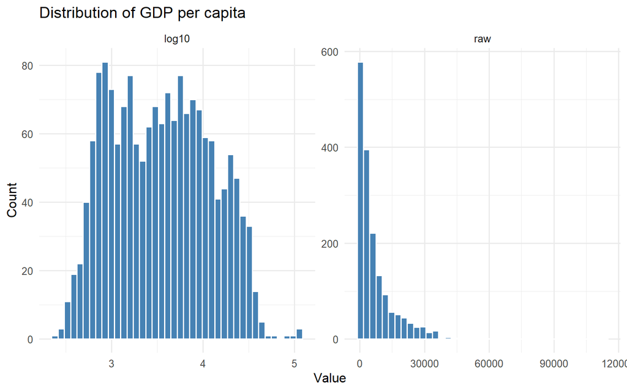

GDP per capita 분포 — 원본(우측 치우침) vs 로그

```r
bind_rows(
  data.frame(value = df$gdpPercap, scale = "raw"),
  data.frame(value = log10(df$gdpPercap), scale = "log10")
) |>
  ggplot(aes(value)) +
  geom_histogram(bins = 40, fill = "steelblue", color = "white") +
  facet_wrap(~scale, scales = "free") +
  labs(title = "Distribution of GDP per capita", x = "Value", y = "Count") + mytheme
```

## 3. 중심경향: 단순평균 vs 인구가중평균

어떤 평균을 쓰느냐가 결론을 바꾼다.

**코드 보기**

```r
sm <- mean(df$lifeExp[df$year == latest])
wm <- with(df[df$year == latest, ], sum(lifeExp * pop) / sum(pop))
data.frame(
  지표 = c("국가 단순평균", "인구 가중평균", "차이"),
  기대수명 = round(c(sm, wm, wm - sm), 2)
) |> kable()
```

| 지표 | 기대수명 |
| --- | --- |
| 국가 단순평균 | 67.01 |
| 인구 가중평균 | 68.92 |
| 차이 | 1.91 |

## 4. 불평등 추세 — 세계는 수렴하는가 발산하는가

가장 중요한 발견. **평균 상승에 가려진 분포 변화**를 본다.

**코드 보기**

```r
ineq <- df |>
  group_by(year) |>
  summarise(
    기대수명_SD = round(sd(lifeExp), 2),
    P90_P10격차 = round(quantile(lifeExp, .9) - quantile(lifeExp, .1), 2),
    소득_변이계수 = round(cv(gdpPercap), 3),
    소득_Gini = round(gini(gdpPercap), 4),
    .groups = "drop"
  )
kable(ineq)
```

| year | 기대수명_SD | P90_P10격차 | 소득_변이계수 | 소득_Gini |
| --- | --- | --- | --- | --- |
| 1952 | 12.23 | 31.40 | 2.502 | 0.5870 |
| 1957 | 12.23 | 31.59 | 2.296 | 0.5848 |
| 1962 | 12.10 | 30.84 | 1.834 | 0.5673 |
| 1967 | 11.72 | 29.99 | 1.476 | 0.5599 |
| 1972 | 11.38 | 29.36 | 1.568 | 0.5718 |
| 1977 | 11.23 | 29.23 | 1.143 | 0.5509 |
| 1982 | 10.77 | 28.96 | 1.029 | 0.5369 |
| 1987 | 10.56 | 28.38 | 1.049 | 0.5476 |
| 1992 | 11.23 | 28.34 | 1.107 | 0.5649 |
| 1997 | 11.56 | 30.08 | 1.119 | 0.5707 |
| 2002 | 12.28 | 32.76 | 1.125 | 0.5736 |
| 2007 | 12.07 | 31.65 | 1.101 | 0.5682 |

**코드 보기**

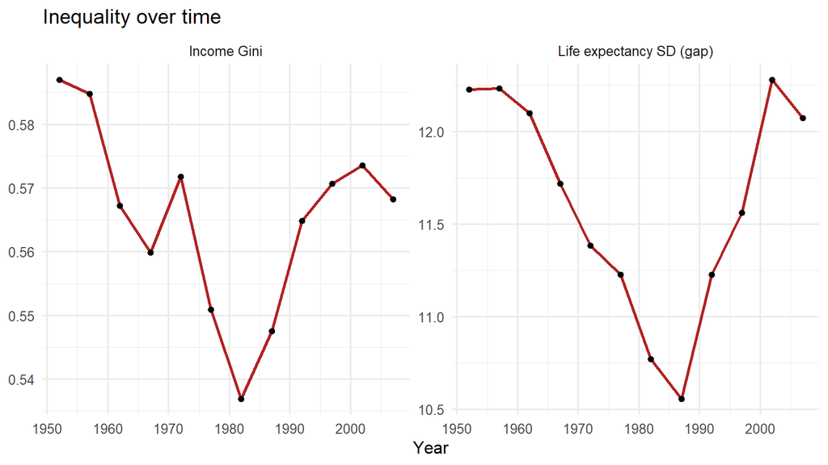

불평등 추세 — 기대수명 격차는 U자형, 소득 Gini는 완만한 완화

```r
df |>
  group_by(year) |>
  summarise(`Life expectancy SD (gap)` = sd(lifeExp),
            `Income Gini` = gini(gdpPercap), .groups = "drop") |>
  pivot_longer(-year) |>
  ggplot(aes(year, value)) +
  geom_line(linewidth = 1, color = "firebrick") + geom_point() +
  facet_wrap(~name, scales = "free_y") +
  labs(title = "Inequality over time", x = "Year", y = NULL) + mytheme
```

기대수명 격차(SD)는 1952~1987년 수렴했다가 **1987~2002년 다시 확대**되는 U자형이다. 이는 사하라이남 HIV/AIDS 충격이 분포의 하단을 끌어내린 결과로, 단순 “전반적 향상” 서술로는 포착되지 않는다.

## 5. 관계 분해 — 심슨의 역설 점검

pooled 상관 하나로 끝내지 않고 연도별·대륙별로 분해한다.

**코드 보기**

```r
cat(sprintf("전체 pooled 상관 cor(lifeExp, log(gdp)) = %.3f\n",
            cor(df$lifeExp, log(df$gdpPercap))))
```

```
전체 pooled 상관 cor(lifeExp, log(gdp)) = 0.808
```

**코드 보기**

```r
by_year <- df |> group_by(year) |>
  summarise(상관 = round(cor(lifeExp, log(gdpPercap)), 3), .groups = "drop")
by_cont <- df |> group_by(continent) |>
  summarise(상관 = round(cor(lifeExp, log(gdpPercap)), 3), .groups = "drop")
kable(by_year, caption = "연도별 상관")
```

연도별 상관

| year | 상관 |
| --- | --- |
| 1952 | 0.748 |
| 1957 | 0.759 |
| 1962 | 0.771 |
| 1967 | 0.773 |
| 1972 | 0.789 |
| 1977 | 0.814 |
| 1982 | 0.846 |
| 1987 | 0.874 |
| 1992 | 0.856 |
| 1997 | 0.864 |
| 2002 | 0.825 |
| 2007 | 0.809 |

**코드 보기**

```r
kable(by_cont, caption = "대륙별 상관")
```

대륙별 상관

| continent | 상관 |
| --- | --- |
| Africa | 0.535 |
| Americas | 0.710 |
| Asia | 0.689 |
| Europe | 0.852 |
| Oceania | 0.960 |

상관은 **모든 연도·대륙에서 양(+)으로 안정적**이므로 심슨의 역설(부호 반전)은 없다. 다만 강도는 Africa(0.54)에서 Oceania(0.96)까지 큰 차이를 보인다.

**코드 보기**

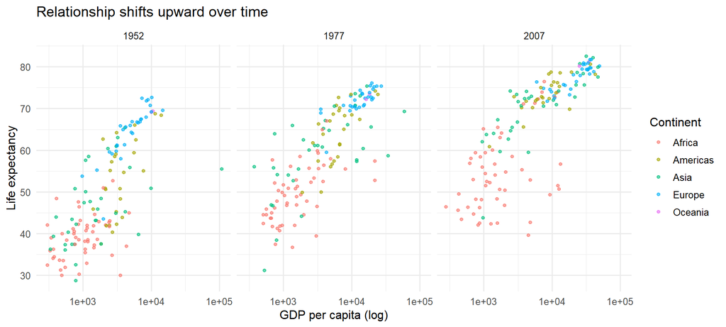

GDP-기대수명 관계는 시간이 지나며 위로 평행이동

```r
df |> filter(year %in% c(1952, 1977, 2007)) |>
  ggplot(aes(gdpPercap, lifeExp, color = continent)) +
  geom_point(alpha = 0.6, size = 1.2) + scale_x_log10() +
  facet_wrap(~year) +
  labs(title = "Relationship shifts upward over time",
       x = "GDP per capita (log)", y = "Life expectancy", color = "Continent") + mytheme
```

## 6. 회귀분석 — 효과 크기 정량화

**코드 보기**

```r
m1 <- lm(lifeExp ~ log(gdpPercap), data = df)
m2 <- lm(lifeExp ~ log(gdpPercap) + continent, data = df)
data.frame(
  모델 = c("M1: lifeExp ~ log(gdp)", "M2: + continent"),
  R2 = round(c(summary(m1)$r.squared, summary(m2)$r.squared), 3),
  `log(gdp)_계수` = round(c(coef(m1)[["log(gdpPercap)"]],
                            coef(m2)[["log(gdpPercap)"]]), 2)
) |> kable()
```

| 모델 | R2 | log.gdp._계수 |
| --- | --- | --- |
| M1: lifeExp ~ log(gdp) | 0.652 | 8.41 |
| M2: + continent | 0.704 | 6.42 |

소득이 e배(약 2.7배) 늘 때 기대수명은 약 **+8.4세**(M1)이다. 대륙 통제 후 계수가 6.4로 줄고 설명력은 0.65→0.70으로 상승한다 → **소득 외 지역 요인(보건·제도)의 기여도 크다.**

**코드 보기**

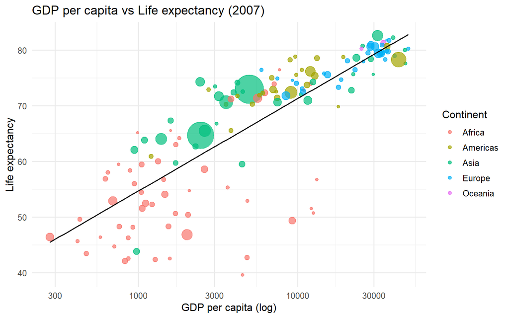

2007년 GDP vs 기대수명 (버블=인구, 회귀선 포함)

```r
df |> filter(year == latest) |>
  ggplot(aes(gdpPercap, lifeExp)) +
  geom_point(aes(size = pop, color = continent), alpha = 0.7) +
  geom_smooth(method = "lm", se = FALSE, color = "black", linewidth = 0.6) +
  scale_x_log10() + scale_size(range = c(1, 15), guide = "none") +
  labs(title = sprintf("GDP per capita vs Life expectancy (%d)", latest),
       x = "GDP per capita (log)", y = "Life expectancy", color = "Continent") + mytheme
```

## 7. 변화 동학 — 성장률과 β-수렴

**코드 보기**

```r
wide <- df |>
  filter(year %in% c(first, latest)) |>
  select(country, continent, year, lifeExp, gdpPercap) |>
  pivot_wider(names_from = year, values_from = c(lifeExp, gdpPercap))
le0 <- paste0("lifeExp_", first);  le1 <- paste0("lifeExp_", latest)
gd0 <- paste0("gdpPercap_", first); gd1 <- paste0("gdpPercap_", latest)
wide <- wide |>
  mutate(lifeExp_gain = .data[[le1]] - .data[[le0]],
         gdp_cagr = (.data[[gd1]] / .data[[gd0]])^(1 / (latest - first)) - 1)
```

**코드 보기**

```r
wide |> arrange(desc(lifeExp_gain)) |>
  transmute(country, continent, 기대수명증가 = round(lifeExp_gain, 1)) |> head(5) |>
  kable(caption = "기대수명 증가 상위 5국")
```

기대수명 증가 상위 5국

| country | continent | 기대수명증가 |
| --- | --- | --- |
| Oman | Asia | 38.1 |
| Vietnam | Asia | 33.8 |
| Indonesia | Asia | 33.2 |
| Saudi Arabia | Asia | 32.9 |
| Libya | Africa | 31.2 |

**코드 보기**

```r
wide |> arrange(lifeExp_gain) |>
  transmute(country, continent, 기대수명증가 = round(lifeExp_gain, 1)) |> head(5) |>
  kable(caption = "기대수명 증가 하위 5국 (정체/역행)")
```

기대수명 증가 하위 5국 (정체/역행)

| country | continent | 기대수명증가 |
| --- | --- | --- |
| Zimbabwe | Africa | -5.0 |
| Swaziland | Africa | -1.8 |
| Zambia | Africa | 0.3 |
| Lesotho | Africa | 0.5 |
| Botswana | Africa | 3.1 |

**코드 보기**

```r
wide |> arrange(desc(gdp_cagr)) |>
  transmute(country, continent, GDP_CAGR_pct = round(gdp_cagr * 100, 2)) |> head(5) |>
  kable(caption = "GDP 연평균성장률(CAGR) 상위 5국")
```

GDP 연평균성장률(CAGR) 상위 5국

| country | continent | GDP_CAGR_pct |
| --- | --- | --- |
| Equatorial Guinea | Africa | 6.53 |
| Taiwan | Asia | 5.93 |
| Korea, Rep. | Asia | 5.84 |
| Singapore | Asia | 5.63 |
| Botswana | Africa | 5.02 |

**코드 보기**

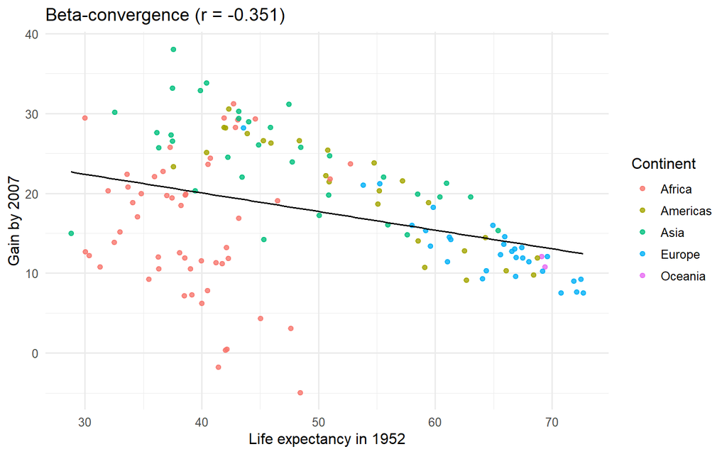

β-수렴 — 출발선이 낮았던 국가일수록 더 많이 따라잡았다

```r
beta <- cor(wide[[le0]], wide$lifeExp_gain)
ggplot(wide, aes(.data[[le0]], lifeExp_gain, color = continent)) +
  geom_point(alpha = 0.8) +
  geom_smooth(method = "lm", se = FALSE, color = "black", linewidth = 0.6) +
  labs(title = sprintf("Beta-convergence (r = %.3f)", beta),
       x = sprintf("Life expectancy in %d", first),
       y = sprintf("Gain by %d", latest), color = "Continent") + mytheme
```

`cor(1952 기대수명, 이후 증가량) = -0.351` 로 음(-)이므로, 뒤처진 국가가 더 빠르게 따라잡는 **β-수렴**이 확인된다.

## 8. 역행 사례 — 평균이 가린 비극

**코드 보기**

```r
df |>
  arrange(country, year) |>
  group_by(country) |>
  mutate(d_life = lifeExp - lag(lifeExp),
         기간 = paste0(lag(year), "→", year)) |>
  ungroup() |>
  filter(!is.na(d_life)) |>
  arrange(d_life) |>
  transmute(country, continent, 기간, 하락폭 = round(d_life, 1)) |>
  head(8) |>
  kable(caption = "5년 새 기대수명이 가장 크게 하락한 구간 TOP 8")
```

5년 새 기대수명이 가장 크게 하락한 구간 TOP 8

| country | continent | 기간 | 하락폭 |
| --- | --- | --- | --- |
| Rwanda | Africa | 1987→1992 | -20.4 |
| Zimbabwe | Africa | 1992→1997 | -13.6 |
| Lesotho | Africa | 1997→2002 | -11.0 |
| Swaziland | Africa | 1997→2002 | -10.4 |
| Botswana | Africa | 1992→1997 | -10.2 |
| Cambodia | Asia | 1972→1977 | -9.1 |
| Namibia | Africa | 1997→2002 | -7.4 |
| South Africa | Africa | 1997→2002 | -6.9 |

르완다(1987→1992, **-20.4세**, 대학살), 짐바브웨·레소토·스와질란드(HIV/AIDS), 캄보디아(1972→1977, 크메르루주) 등 — 평균 추세로는 결코 보이지 않는 충격들이다.

## 9. 핵심 인사이트 & 후속 분석

**후속 분석 제안**

- 국가별 기대수명 성장 속도(연평균)와 수렴 클럽(convergence club) 식별
- 산유국(고GDP–저수명) 등 회귀 잔차가 큰 이상치 사례 심층 분석
- 최신 Gapminder 원자료(2007년 이후)로 확장하여 코로나·최근 동향 반영

*본 보고서는 `data/gapminder.csv`를 대상으로 Quarto로 작성되었으며, 모든 표·그림은 문서 렌더링 시 코드에서 직접 생성된다(재현 가능).*